# Audio Retrieval MS1

This project focuses on audio retrieval using constellation maps, inspired by prior work on audio fingerprinting and matching (Please see the `README.md` in the Acknowledgements/Credits section for more information). Milestone 1 involves evaluating various configurations for generating constellation maps and testing their effectiveness in retrieving audio files under different query conditions, such as unmodified, noisy, compressed, and mobile-recorded audio. By analyzing retrieval metrics such as TP, hit rate, and retrieval time, we aim to identify optimal configurations for future use.

The main objectives include:

1. Data and Query Preparation: Transforming the MTG-Jamendo dataset into query tracks with specific distortions and formats to simulate real-world scenarios.
2. Database Preparation: Creating constellation maps for audio tracks with varying parameter configurations.
3. Retrieval Experimentation: Evaluating the retrieval performance across different configurations and tolerance settings.

This notebooks documents the design choices, results, and findings, providing a detailed analysis of retrieval performance through visualizations and metrics.

## Task 1: Obtaining Data and Query Processing

We obtained the data from the MTG-Jamendo dataset. We used the 04 of the many tarballs available. The data can be downloaded [here](https://cdn.freesound.org/mtg-jamendo/raw_30s/audio/raw_30s_audio-04.tar) or alternatively via this command which places the files already in the correct folder.

```
wget https://cdn.freesound.org/mtg-jamendo/raw_30s/audio/raw_30s_audio-04.tar
tar -xvf raw_30s_audio-04.tar -C data
```

Next we randomly selected 20 tracks representing the query tracks. For each of the selected files, we extracted an approx. 10 sec segment starting at a random position within the first 20 seconds. We did this with tools such as Audacity and FFmpeg (please see the folder `queries`for the corresponding .sh files used for automating the process). The Mobile transformation was done by playing/recording the audio with two mobile phones in a park.

We created differently distorted versions of the query tracks by applying the following transformations:

- Original: unmodified 10 sec segment
- Noise: added Gaussian noise to the segment
- Coding: compressed representation
- Mobile: outdoor recording with a mobile phone in an urban setting

The query tracks with the transformations are stored in the `queries` folder.  
The MTG-Jamendo dataset provides mp3 files. We converted all `.mp3` files of the queries to the `.wav` format because `.wav` provides lossless audio quality, ensuring more accurate spectrogram generation and audio analysis.

As a first step in this notebook. Let's create a method used for loading the query and the data files.

```python
import os

def get_files(directory='../data', endswith='.wav'):
    """Function to get all files with the specified extension in a directory and its subdirectories."""
    files = []
    for root, _, fs in os.walk(directory):
        for f in fs:
            if f.endswith(endswith):
                files.append(os.path.join(root, f))
    return files
```

## Task 2: Database Preparation

For this task, we will create constellation maps for the first 30 seconds of each track in the database. The steps include:

1. Loading the first 30 seconds of audio files.
2. Computing the spectrograms using Short-Time Fourier Transform (STFT).
3. Generating constellation maps with different configurations for neighborhood parameters (`κ`, `τ`).
4. Storing the results in memory and optionally saving them to disk.

First let's define a helper method to compute the spectrogram and to compute and plot the constellation maps.

```python
import os, sys
import numpy as np
import librosa
from scipy import ndimage
import matplotlib.pyplot as plt

def compute_constellation_map(Y, dist_freq=7, dist_time=7, thresh=0.01):
    """Compute constellation map from a spectrogram Y."""
    result = ndimage.maximum_filter(Y, size=[2*dist_freq+1, 2*dist_time+1], mode='constant')
    Cmap = np.logical_and(Y == result, result > thresh)
    return Cmap

def plot_constellation_map(Cmap, Y=None, xlim=None, ylim=None, title='',
                           xlabel='Time (sample)', ylabel='Frequency (bins)',
                           s=5, color='r', marker='o', figsize=(7, 3), dpi=72):
    """Plot constellation map on top of a spectrogram"""
    if Cmap.ndim > 1:
        (K, N) = Cmap.shape
    else:
        K = Cmap.shape[0]
        N = 1
    if Y is None:
        Y = np.zeros((K, N))
    fig, ax = plt.subplots(1, 1, figsize=figsize, dpi=dpi)
    im = ax.imshow(Y, origin='lower', aspect='auto', cmap='gray_r', interpolation='nearest')
    ax.set_xlabel(xlabel)
    ax.set_ylabel(ylabel)
    ax.set_title(title)
    Fs = 1
    if xlim is None:
        xlim = [-0.5/Fs, (N-0.5)/Fs]
    if ylim is None:
        ylim = [-0.5/Fs, (K-0.5)/Fs]
    ax.set_xlim(xlim)
    ax.set_ylim(ylim)
    n, k = np.argwhere(Cmap == 1).T
    ax.scatter(k, n, color=color, s=s, marker=marker)
    plt.tight_layout()
    return fig, ax, im

def compute_spectrogram(fn_wav, Fs=22050, N=2048, H=1024, bin_max=128, frame_max=None):
    """Compute spectrogram for a given audio file"""
    #x, Fs = librosa.load(fn_wav, Fs)
    x, Fs = librosa.load(fn_wav, sr=Fs, duration=30)
    x_duration = len(x) / Fs
    X = librosa.stft(x, n_fft=N, hop_length=H, win_length=N, window='hann')
    if bin_max is None:
        bin_max = X.shape[0]
    if frame_max is None:
        frame_max = X.shape[0]
    Y = np.abs(X[:bin_max, :frame_max])
    return Y
```

We will process the following configurations for the constellation map:

- `(κ=8, τ=2)`
- `(κ=11, τ=3)`
- `(κ=15, τ=4)`
- `(κ=17, τ=5)`

The chosen parameters for the constellation map configurations are based on prior research outlined in the work from Audio Identification [IPython Notebook](https://www.audiolabs-erlangen.de/resources/MIR/FMP/C7/C7S1_AudioIdentification.ipynb) with new similar configurations added.

The next step is to load the files for the database from the folder `../data/04`.

```python
# Example configurations
configurations = [
    (8, 2),  # (κ=8, τ=2)
    (11, 3),  # (κ=11, τ=3)
    (15, 4), # (κ=15, τ=4)
    (17, 5),  # (κ=17, τ=5)
]

# File list for processing
file_list = get_files(directory='../data/04', endswith=".mp3")
```

We will compute constellation maps for each file and configuration and store the results in memory. Optionally, the maps can be saved as `.npz` files for later use.

```python
def prepare_database(file_list, configurations, Fs=22050, N=2048, H=1024, bin_max=128, frame_max=None):
    """Prepare database by computing constellation maps for all configurations"""
    database = {}
    print(f"Processing {len(file_list)} files...")
    for file in file_list:

        # Compute spectrogram for the current file
        Y = compute_spectrogram(file, Fs=Fs, N=N, H=H, bin_max=bin_max, frame_max=frame_max)

        # Retrieve metadata for the file
        file_size = os.path.getsize(file)  # Size in bytes
        duration = librosa.get_duration(path=file)  # Duration in seconds

        # Initialize nested structure for the current file
        file_key = os.path.basename(file)
        database[file_key] = {
            "metadata": {
                "size": file_size,
                "original_query_id": os.path.splitext(file_key)[0],
            },
            "constellation_maps": {}
        }

        # Compute constellation maps for all configurations
        for (dist_freq, dist_time) in configurations:
            cmap = compute_constellation_map(Y, dist_freq=dist_freq, dist_time=dist_time)
            database[file_key]["constellation_maps"][(dist_freq, dist_time)] = cmap
    print("Processing done.")
    return database


# Prepare database
database = prepare_database(file_list, configurations)
```

```
Processing 556 files...
Processing done.
```

We will visualize the constellation maps for the first file (with all the configurations) in the database. Each constellation map will show:

1. The spectrogram of the audio.
2. The detected peaks for one selected configuration.

This will help us verify that the constellation maps are being computed correctly.

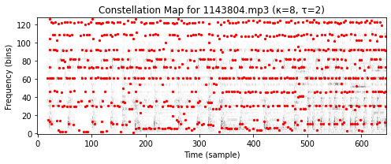

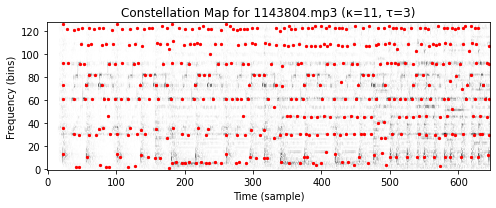

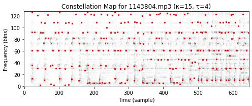

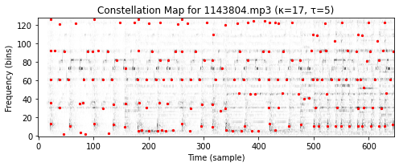

```python
# Display constellation maps for the first file with all configurations
first_file = file_list[0]

# Compute the spectrogram for the first file
Y = compute_spectrogram(first_file, Fs=22050, N=2048, H=1024, bin_max=128)

# Plot constellation maps for all configurations
for dist_freq, dist_time in configurations:
    cmap = compute_constellation_map(Y, dist_freq=dist_freq, dist_time=dist_time)
    title = f"Constellation Map for {os.path.basename(first_file)} (κ={dist_freq}, τ={dist_time})"
    plot_constellation_map(cmap, Y=Y, title=title)
```

The generated constellation maps can be saved to disk for later use. Each map will be stored as an `.npz` file. (Optional)

```python
output_folder = "constellations"
os.makedirs(output_folder, exist_ok=True)

for key, cmap in database.items():
    np.savez_compressed(os.path.join(output_folder, f"{key}.npz"), cmap=cmap)

print(f"Saved constellation maps to {output_folder}")
```

```
Saved constellation maps to constellations
```

## Task 3: Retrieval Experimentation

In this section, we perform retrieval experiments by:

1. Calculating constellation maps for the queries created in Task 1.
2. Comparing each query's constellation map with all maps in the database.
3. Identifying the best match by sliding the query constellation map over each database map and calculating the overlap.
4. Evaluating the performance of the retrieval system using different metrics.
5. Visualization of the results.
6. Analyzing the impact of different tolerance settings (`tol_freq`, `tol_time`) and configurations (`κ`, `τ`) and determining the best choice for future work.

First let's create the constellation maps for the query files. We will use the same configurations as before for the database.

```python
def prepare_query_constellation_maps(file_list, configurations, Fs=22050, N=2048, H=1024, bin_max=128, frame_max=None):
    """Compute query constellation maps for all configurations and save the results in a nested structure."""
    query_maps = {}
    for file in file_list:

        # Compute spectrogram for the current file
        Y = compute_spectrogram(file, Fs=Fs, N=N, H=H, bin_max=bin_max, frame_max=frame_max)

        # Retrieve metadata for the file
        file_size = os.path.getsize(file)  # Size in bytes

        # Initialize nested structure for the current query
        file_key = os.path.basename(file)
        query_maps[file_key] = {
            "metadata": {
                "size": file_size,
                "original_query_id": file_key.split('_')[0],
            },
            "constellation_maps": {}
        }

        # Compute constellation maps for all configurations
        for (dist_freq, dist_time) in configurations:
            cmap = compute_constellation_map(Y, dist_freq=dist_freq, dist_time=dist_time)
            query_maps[file_key]["constellation_maps"][(dist_freq, dist_time)] = cmap
    return query_maps

query_list_original = get_files(directory='../queries/cut_output', endswith=".wav")
query_list_noise = get_files(directory='../queries/noise_output', endswith=".wav")
query_list_coding = get_files(directory='../queries/coding_output', endswith=".wav")
query_list_mobile = get_files(directory='../queries/mobile_output', endswith=".wav")

count = len(query_list_original) + len(query_list_noise) + len(query_list_coding) + len(query_list_mobile)

# Print the total number of files to be processed
print(f"Processing {count} query files...")
query_C_original = prepare_query_constellation_maps(query_list_original, configurations)
query_C_noise = prepare_query_constellation_maps(query_list_noise, configurations)
query_C_coding = prepare_query_constellation_maps(query_list_coding, configurations)
query_C_mobile = prepare_query_constellation_maps(query_list_mobile, configurations)
print("Processing done.")
```

```
Processing 80 query files...
Processing done.
```

Now let's define some helper methods to perform the retrieval experiments.

The compute_matching_function and match_binary_matrices_tol are functions used in the referenced notebook from audiolabs-erlangen (look in reference section of `README.md` for more information). After some testing we noticed that this is a very time-consuming process and we need to optimize the code in order to do evaluation in a reasonable time.

We will use the compute_matching_function_numba for faster computation. This function is a numba-accelerated version of the compute_matching_function which incorporates parallelization for faster computation. The primary reason for choosing the TP metric is its direct reflection of the number of matching peaks between the query constellation map and the document constellation map. Our objective is to identify the best match, and maximizing the number of common peaks is a sufficient and robust criterion for this task.

In contrast, metrics such as precision, recall, and F-score may introduce instability in scenarios with highly distorted or noisy queries. These queries often contain additional peaks due to noise or transformation artifacts, leading to an inflated number of false positives (FPs) or false negatives (FNs). This can cause precision and recall to vary significantly, potentially reducing the reliability of the system's performance evaluation. By focusing on the TP metric, we ensure a more straightforward and robust matching process.

```python
from numba import prange, jit


def compute_matching_function(C_D, C_Q, tol_freq=0, tol_time=0):
    """Compute the matching function for a query constellation map and a document constellation map."""
    L = C_D.shape[1]
    N = C_Q.shape[1]
    M = L - N
    assert M >= 0, "Query must be shorter than document"
    Delta = np.zeros(L)
        # Expand C_est with 2D-max-filter using the tolerance parameters
    C_est_max = ndimage.maximum_filter(C_Q, size=(2*tol_freq+1, 2*tol_time+1),
                                       mode='constant')
    for m in range(M + 1):
        C_D_crop = C_D[:, m:m+N]
        TP, FN, FP, C_AND = match_binary_matrices_tol(C_D_crop, C_Q, C_est_max)
        precision = TP / (TP + FP) if (TP + FP) > 0 else 0
        recall = TP / (TP + FN) if (TP + FN) > 0 else 0
        score = (2 * precision * recall) / (precision + recall) if (precision + recall) > 0 else 0

        Delta[m] = score
    shift_max = np.argmax(Delta)
    return Delta, shift_max

def match_binary_matrices_tol(C_ref, C_est, C_est_max):
    assert C_ref.shape == C_est.shape, "Dimensions need to agree"
    N = np.sum(C_ref)
    M = np.sum(C_est)

    C_AND = np.logical_and(C_est_max, C_ref)
    TP = np.sum(C_AND)
    FN = N - TP
    FP = M - TP
    return TP, FN, FP, C_AND

@jit(nopython=True, parallel=True)
def compute_matching_function_numba(C_D, C_Q, C_est_max, tol_freq=0, tol_time=0):
    """Numba-accelerated computation of the matching function."""
    L = C_D.shape[1]
    N = C_Q.shape[1]
    M = L - N
    Delta = np.zeros(M + 1, dtype=np.float64)

    for m in prange(M + 1):
        C_D_crop = C_D[:, m:m + N]
        TP = np.sum(np.logical_and(C_est_max, C_D_crop))
        #FN = np.sum(C_D_crop) - TP
        #FP = np.sum(C_Q) - TP
        #precision = TP / (TP + FP + 1e-10)
        #recall = TP / (TP + FN + 1e-10)
        #score = (2 * precision * recall) / (precision + recall + 1e-10)
        Delta[m] = TP

    shift_max = np.argmax(Delta)
    return Delta, shift_max
```

Now, let's do a test for the first query file (3904) to see if it works.

```python
originalQuery = query_C_original["3904_cut.wav"]["constellation_maps"][(8, 2)]
tol_freq = 0
tol_time = 0

C_est_max_forQuery = ndimage.maximum_filter(originalQuery, size=(2*tol_freq+1, 2*tol_time+1), mode='constant')


Delta, shiftmax = compute_matching_function_numba(database["3904.mp3"]["constellation_maps"][(8, 2)], originalQuery,C_est_max_forQuery, tol_freq, tol_time)

print(f'maximal value of 2 matching queries: {Delta[shiftmax]}')

Delta, shiftmax = compute_matching_function_numba(database["1121404.mp3"]["constellation_maps"][(8, 2)], originalQuery, C_est_max_forQuery, tol_freq, tol_time)

print(f'maximal value of 2 non matching queries: {Delta[shiftmax]}')

Delta, shiftmax = compute_matching_function_numba(database["7204.mp3"]["constellation_maps"][(8, 2)], originalQuery, C_est_max_forQuery, tol_freq, tol_time)

print(f'maximal value of 2 non matching queries: {Delta[shiftmax]}')
```

```
maximal value of 2 matching queries: 97.0
maximal value of 2 non matching queries: 12.0
maximal value of 2 non matching queries: 15.0
```

This shows us that the matching function is working. Now let's check how fast it is to evaluate one query against all the database files.

```python
import time

def evaluate_query(Q_C, database, configuration, tol_freq=0, tol_time=0):
    start_time = time.time()

    top_result = None
    top_score = -1
    i = 0
    for database_key, database_data in database.items():
        i += 1
        D_C = database_data["constellation_maps"][configuration]

        C_est_max = ndimage.maximum_filter(Q_C, size=(2*tol_freq+1, 2*tol_time+1), mode='constant')
        #Delta, shift_max = compute_matching_function(D_C, Q_C, tol_freq, tol_time)
        Delta, shift_max = compute_matching_function_numba(D_C, Q_C, C_est_max, tol_freq, tol_time)
        score = Delta[shift_max]

        if score > top_score:
            top_score = score
            top_result = (database_key, score)

    #print(f'Processed {i} files')
    elapsed_time = time.time() - start_time

    return top_result, elapsed_time

result, time = evaluate_query(query_C_original["3904_cut.wav"]["constellation_maps"][(8, 2)], database, (8, 2))
#result, time = evaluate_query(query_C_mobile["3904_cut_mobile.wav"]["constellation_maps"][(8, 2)], database, (8, 2))
#result, time = evaluate_query(query_C_coding["1227104_cut_coding.wav"]["constellation_maps"][(8, 2)], database, (8, 2))


print(f'Retrieved top result: {result} in {time} seconds')
```

```
Retrieved top result: ('3904.mp3', 97.0) in 0.5782530307769775 seconds
```

Perfect, the evaluation is working. The best overlap is identified by sliding the query constellation map sample-by-sample over each constellation map in the database. Of course there are optimizations to this approach, but for now we will work with this to perform retrieval experiments:

First of all, let's evaluate all original queries (10sec, unmodified) against the database with all configurations. For each query we want to record the time it took, we want to see if the correct music piece is retrieved, and we want to record the TP score. Then for all the distorted/transformed queries we also want to record time, if it was a hit, and the TP score. By doing this we can compare different configurations of κ and τ (i.e, dist_freq and dist_time, resp.).

Additionally, we want to redo the evaluation with different tolerance values (tol_freq and tol_time) to see how this affects the retrieval performance. The first evaluation will be without tolerance `tol_freq=0, tol_time=0` and the second with tolerance `tol_freq=1, tol_time=1`.

We chose to record the results in a csv file for persistence (in the folder `evaluation`). Please note that the whole evaluation process can take a long time. On my machine it took around 6 minutes to evaluate all queries against the database with all configurations and tolerance settings. For more information on the test setup please see the `evaluation/README.md`.

```python
import csv
import time

def evaluate_queries(query_constellation_maps, database, configuration, tol_freq, tol_time, output_file):
    output_dir = os.path.join("..", "evaluation")
    os.makedirs(output_dir, exist_ok=True)
    output_path = os.path.join(output_dir, output_file)


    with open(output_path, mode='w', newline='') as file:
        writer = csv.writer(file)
        #writer.writerow(["Query", "dist_freq", "dist_time", "tol_freq", "tol_time", "Hit", "F-measure" , "Time (s)"])
        writer.writerow(["Query", "Original Query name", "dist_freq", "dist_time", "tol_freq", "tol_time", "Hit", "TP" , "Time (s)"])
        for query_key, query_data in query_constellation_maps.items():
            Q_C = query_data["constellation_maps"][configuration]
            result, elapsed_time = evaluate_query(Q_C, database, configuration, tol_freq, tol_time)
            original_query_name = database[result[0]]["metadata"]["original_query_id"]
            hit = 1 if original_query_name == query_constellation_maps[query_key]["metadata"]["original_query_id"] else 0
            writer.writerow([query_key, original_query_name, configuration[0], configuration[1], tol_freq, tol_time, hit, result[1], elapsed_time])

for configuration in configurations:
    dist_freq, dist_time = configuration
    evaluate_queries(query_C_original, database, configuration, 0, 0, f"results_original_k{dist_freq}_t{dist_time}_tol00.csv")
    print(f"Results original for configuration {configuration} saved.")
    evaluate_queries(query_C_noise, database, configuration, 0, 0, f"results_noise_k{dist_freq}_t{dist_time}_tol00.csv")
    print(f"Results noise for configuration {configuration} saved.")
    evaluate_queries(query_C_coding, database, configuration, 0, 0, f"results_coding_k{dist_freq}_t{dist_time}_tol00.csv")
    print(f"Results coding for configuration {configuration} saved.")
    evaluate_queries(query_C_mobile, database, configuration, 0, 0, f"results_mobile_k{dist_freq}_t{dist_time}_tol00.csv")
    print(f"Results mobile for configuration {configuration} saved.")

    # Evaluate with tolerance
    evaluate_queries(query_C_original, database, configuration, 1, 1, f"results_original_k{dist_freq}_t{dist_time}_tol11.csv")
    print(f"Results original for configuration {configuration} with tolerance saved.")
    evaluate_queries(query_C_noise, database, configuration, 1, 1, f"results_noise_k{dist_freq}_t{dist_time}_tol11.csv")
    print(f"Results noise for configuration {configuration} with tolerance saved.")
    evaluate_queries(query_C_coding, database, configuration, 1, 1, f"results_coding_k{dist_freq}_t{dist_time}_tol11.csv")
    print(f"Results coding for configuration {configuration} with tolerance saved.")
    evaluate_queries(query_C_mobile, database, configuration, 1, 1, f"results_mobile_k{dist_freq}_t{dist_time}_tol11.csv")
    print(f"Results mobile for configuration {configuration} with tolerance saved.")
```

```
Results original for configuration (8, 2) saved.
Results noise for configuration (8, 2) saved.
Results coding for configuration (8, 2) saved.
Results mobile for configuration (8, 2) saved.
Results original for configuration (8, 2) with tolerance saved.
Results noise for configuration (8, 2) with tolerance saved.
Results coding for configuration (8, 2) with tolerance saved.
Results mobile for configuration (8, 2) with tolerance saved.
Results original for configuration (11, 3) saved.
Results noise for configuration (11, 3) saved.
Results coding for configuration (11, 3) saved.
Results mobile for configuration (11, 3) saved.
Results original for configuration (11, 3) with tolerance saved.
Results noise for configuration (11, 3) with tolerance saved.
Results coding for configuration (11, 3) with tolerance saved.
Results mobile for configuration (11, 3) with tolerance saved.
Results original for configuration (15, 4) saved.
Results noise for configuration (15, 4) saved.
Results coding for configuration (15, 4) saved.
Results mobile for configuration (15, 4) saved.
Results original for configuration (15, 4) with tolerance saved.
Results noise for configuration (15, 4) with tolerance saved.
Results coding for configuration (15, 4) with tolerance saved.
Results mobile for configuration (15, 4) with tolerance saved.
Results original for configuration (17, 5) saved.
Results noise for configuration (17, 5) saved.
Results coding for configuration (17, 5) saved.
Results mobile for configuration (17, 5) saved.
Results original for configuration (17, 5) with tolerance saved.
Results noise for configuration (17, 5) with tolerance saved.
Results coding for configuration (17, 5) with tolerance saved.
Results mobile for configuration (17, 5) with tolerance saved.
```

### Evaluation of the results

Now let's evaluate the results of the retrieval experiment. We will analyze the CSV files generated during the experiments. We want to calculate the average time, hit rate, and TP score for each configuration and query type. We also want to know what the maximum/minimum values are for time taken and TP score. At the end we want to see what configuration is best suited for the task and for further development.

Since we also reevaluated all queries with tolerance, we will analyze the results with tolerance (tol11) and without tolerance (tol00) separately and compare the results to determine what setting is better suited.

We also want to incorporate some visualizations to better understand the results.

First let's define some helper functions to load the csv files and store them into a fitting datastructure.

Remark: The following text snippets are based on the results in the `evaluation` folder, if you ran the code on your own, the values might differ. Again, for more information on the test setup please see the `evaluation/README.md`.

```python
from pathlib import Path

# Helper function to load results from a single file
def load_results(file_path):
    """Load retrieval results from a CSV file."""
    return pd.read_csv(file_path)

# Helper function to load and combine multiple CSV files
def load_all_results(folder_path, tolerance="None"):
    """Load all CSV files in a folder and combine them into a single DataFrame."""
    all_files = Path(folder_path).glob("*.csv")
    if tolerance != "None":
        all_files = [f for f in all_files if tolerance in f.stem]   # Filter files by tolerance
    dfs = []
    #print(all_files)
    for file in all_files:
        df = pd.read_csv(file)
        df["Source"] = file.stem  # Add a source column for file identification
        dfs.append(df)
    return pd.concat(dfs, ignore_index=True)
```

Let's load the results from all the CSV files generated during the evaluation process. First we will analyze the data analyzed without tolerance values (tol00). Later we will analyze the results with tolerance (tol11).

```python
# Load and Combine Data from Multiple Files
results_folder = "../evaluation"
df_combined_tol00 = load_all_results(results_folder, tolerance="tol00")

# Display combined data information
print("Combined Data Overview:")
print(df_combined_tol00.info())
print(df_combined_tol00.head())
```

```
Combined Data Overview:
<class 'pandas.core.frame.DataFrame'>
RangeIndex: 320 entries, 0 to 319
Data columns (total 10 columns):
 #   Column               Non-Null Count  Dtype
---  ------               --------------  -----
 0   Query                320 non-null    object
 1   Original Query name  320 non-null    int64
 2   dist_freq            320 non-null    int64
 3   dist_time            320 non-null    int64
 4   tol_freq             320 non-null    int64
 5   tol_time             320 non-null    int64
 6   Hit                  320 non-null    int64
 7   TP                   320 non-null    float64
 8   Time (s)             320 non-null    float64
 9   Source               320 non-null    object
dtypes: float64(2), int64(6), object(2)
memory usage: 25.1+ KB
None
                   Query  Original Query name  dist_freq  dist_time  tol_freq  \
0   903604_cut_noise.wav               903604         15          4         0
1  1227104_cut_noise.wav              1227104         15          4         0
2   863504_cut_noise.wav               863504         15          4         0
3  1110504_cut_noise.wav              1110504         15          4         0
4  1299504_cut_noise.wav              1299504         15          4         0

   tol_time  Hit    TP  Time (s)                      Source
0         0    1  37.0  0.474273  results_noise_k15_t4_tol00
1         0    1  11.0  0.475059  results_noise_k15_t4_tol00
2         0    1  30.0  0.473114  results_noise_k15_t4_tol00
3         0    1  60.0  0.473461  results_noise_k15_t4_tol00
4         0    1  22.0  0.471577  results_noise_k15_t4_tol00
```

Perfect, now that we have the data loaded, let's analyze the results. We do not have to worry about missing values as the data is complete.

```python
import pandas as pd

def summarize_overall_metrics(df):
    """Summarize overall metrics from the retrieval experiment."""
    # Calculate overall time statistics
    avg_time = df["Time (s)"].mean()
    median_time = df["Time (s)"].median()
    max_time = df["Time (s)"].max()
    min_time = df["Time (s)"].min()

    # Calculate overall TP statistics
    avg_tp = df["TP"].mean()
    max_tp = df["TP"].max()
    min_tp = df["TP"].min()

    # Get query details for max and min metrics
    max_time_query = df[df["Time (s)"] == max_time]["Query"].values[0]
    min_time_query = df[df["Time (s)"] == min_time]["Query"].values[0]
    max_time_file = df[df["Time (s)"] == max_time]["Source"].values[0]
    min_time_file = df[df["Time (s)"] == min_time]["Source"].values[0]

    max_tp_query = df[df["TP"] == max_tp]["Query"].values[0]
    min_tp_query = df[df["TP"] == min_tp]["Query"].values[0]
    max_tp_file = df[df["TP"] == max_tp]["Source"].values[0]
    min_tp_file = df[df["TP"] == min_tp]["Source"].values[0]

    # Calculate hit rate
    avg_hit_rate = df["Hit"].mean()

    # Create a summary dictionary
    summary = {
        "Metric": [
            "Number of Queries",
            "Average Time (s)",
            "Median Time (s)",
            "Max Time (s)",
            "Min Time (s)",
            "Average TP",
            "Max TP",
            "Min TP",
            "Average Hit Rate"
        ],
        "Value": [
            len(df),
            f"{avg_time:.2f}",
            f"{median_time:.2f}",
            f"{max_time:.2f} (Query: {max_time_query})",
            f"{min_time:.2f} (Query: {min_time_query})",
            f"{avg_tp:.2f}",
            f"{max_tp:.2f} (Query: {max_tp_query})",
            f"{min_tp:.2f} (Query: {min_tp_query})",
            f"{avg_hit_rate:.2f}"
        ],
        "File": [
            "",
            "",
            "",
            f"{max_time_file}.csv",
            f"{min_time_file}.csv",
            "",
            f"{max_tp_file}.csv",
            f"{min_tp_file}.csv",
            ""
        ]
    }

    # Convert to a DataFrame for tabular display
    summary_df = pd.DataFrame(summary)

    # Style the table for better visual appearance
    styled_summary_df = (
        summary_df.style
        .set_properties(**{'text-align': 'left', 'border': '1px solid black'})
        .set_table_styles([
            {'selector': 'th', 'props': [('font-weight', 'bold'), ('text-align', 'left'), ('background-color', '#f4f4f4')]},
            {'selector': 'td', 'props': [('padding', '8px')]},
            {'selector': 'tr:hover', 'props': [('background-color', '#f0f0f0')]},
        ])
        .set_caption("Summary of Retrieval Metrics")
        .format(na_rep="-")
    )

    return styled_summary_df

summary_metrics = summarize_overall_metrics(df_combined_tol00)
summary_metrics
```

Summary of Retrieval Metrics

|  | Metric | Value | File |
| --- | --- | --- | --- |
| 0 | Number of Queries | 320 |  |
| 1 | Average Time (s) | 0.47 |  |
| 2 | Median Time (s) | 0.47 |  |
| 3 | Max Time (s) | 0.64 (Query: 903604_cut.wav) | results_original_k8_t2_tol00.csv |
| 4 | Min Time (s) | 0.46 (Query: 1330504_cut_mobile.wav) | results_mobile_k17_t5_tol00.csv |
| 5 | Average TP | 49.15 |  |
| 6 | Max TP | 246.00 (Query: 1132204_cut.wav) | results_original_k8_t2_tol00.csv |
| 7 | Min TP | 4.00 (Query: 1121404_cut_mobile.wav) | results_mobile_k17_t5_tol00.csv |
| 8 | Average Hit Rate | 0.95 |  |

Already with this information, we can derive some interesting insights. The average time taken for the queries to retrieve the best model is around `0.47 seconds` which is quite fast. The optimization of the code with numba has helped to speed up the process.

The average TP of `49.15` indicates moderate accuracy across the board. However, the perfect TP score of `246` for the query `1132204_cut.wav` demonstrates the system's potential under ideal conditions. Conversely, the query `1121404_cut_mobile.wav`, with an TP Score of `4`, underscores the challenges associated with queries recorded in outdoor urban settings.

The average hit rate of `0.95` is quite high, indicating that the system can correctly identify the original query track in most cases.

This leads us to do some further analysis on the different transformations.

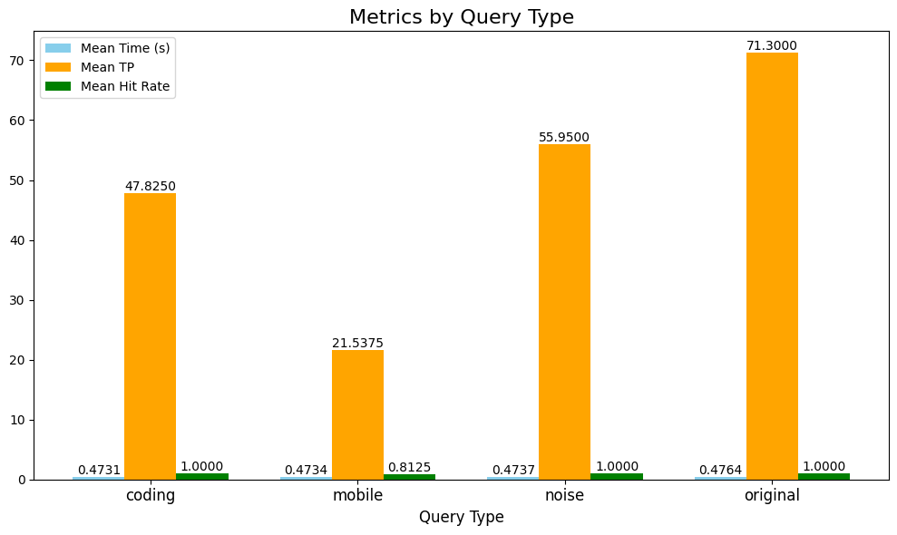

```python
import matplotlib.pyplot as plt
import numpy as np

def analyze_query_types(df):
    """Analyzes and visualizes metrics by query types (coding, noise, mobile, original)."""
    # Assign query type based on substrings in the query column
    df["Query Type"] = df["Query"].apply(
        lambda x: "coding" if "coding" in x else ("noise" if "noise" in x else ("mobile" if "mobile" in x else "original"))
    )

    # Group metrics by query type
    grouped_metrics = df.groupby("Query Type").agg(
        mean_time=("Time (s)", "mean"),
        mean_f_measure=("TP", "mean"),
        mean_hit_rate=("Hit", "mean")
    ).reset_index()

    # Extract metrics for plotting
    query_types = grouped_metrics["Query Type"]
    mean_times = grouped_metrics["mean_time"]
    mean_f_measures = grouped_metrics["mean_f_measure"]
    mean_hit_rates = grouped_metrics["mean_hit_rate"]

    # Creating the bar plot
    x = np.arange(len(query_types))  # Label locations
    width = 0.25  # Bar width

    fig, ax = plt.subplots(figsize=(10, 6))

    # Create bars for each metric
    bar1 = ax.bar(x - width, mean_times, width, label='Mean Time (s)', color='skyblue')
    bar2 = ax.bar(x, mean_f_measures, width, label='Mean TP', color='orange')
    bar3 = ax.bar(x + width, mean_hit_rates, width, label='Mean Hit Rate', color='green')

    # Adding labels, title, and legend
    ax.set_xlabel('Query Type', fontsize=12)
    ax.set_title('Metrics by Query Type', fontsize=16)
    ax.set_xticks(x)
    ax.set_xticklabels(query_types, fontsize=12)
    ax.legend()

    # Adding values on top of the bars
    def add_labels(bars):
        for bar in bars:
            height = bar.get_height()
            ax.text(bar.get_x() + bar.get_width() / 2.0, height, f'{height:.4f}', ha='center', va='bottom', fontsize=10)

    add_labels(bar1)
    add_labels(bar2)
    add_labels(bar3)

    plt.tight_layout()
    plt.show()

    return grouped_metrics

# Example usage
grouped_metrics_query_types = analyze_query_types(df_combined_tol00)
```

#### Mean Time (blue bars):

- The mean time for all query types (coding, mobile, noise, and original) is fairly consistent.
- This indicates that the retrieval system performs similarly in terms of time efficiency across all query types.

#### Mean TP score(orange bars):

- The mean TP varies more noticeably between query types:
  - **Original queries** achieve the highest mean TP of `71.3`, showcasing the system's strongest performance with unaltered data.
  - **Noise queries** perform slightly worse with a mean TP of `55.95`.
  - **Coding queries** perform similarly to coding, with a mean TP of `47.83`. This suggests that the systems is more robust to noise than to coding. But of course this also depends on how strong the noise is and how the coding was done.
  - **Mobile queries** have the lowest mean TP at `21.54`, indicating that recordings in outdoor or noisy environments are the most challenging for the system to handle. This was also observed in the reference notebook of audiolabs-erlangen [previous work and analysis](https://www.audiolabs-erlangen.de/resources/MIR/FMP/C7/C7S1_AudioIdentification.ipynb).

#### Mean Hit Rate (green bars):

- The mean hit rate is `1.0` for Original, Coding and Noise query types, suggesting that the system correctly identifies the target track.
- The Mobile queries have a mean hit rate of `0.81` which is still high, but shows that the system does not always correctly identify the target track in outdoor urban settings.

Next, we will analyze if the results change when we consider the different configurations of constellation maps.

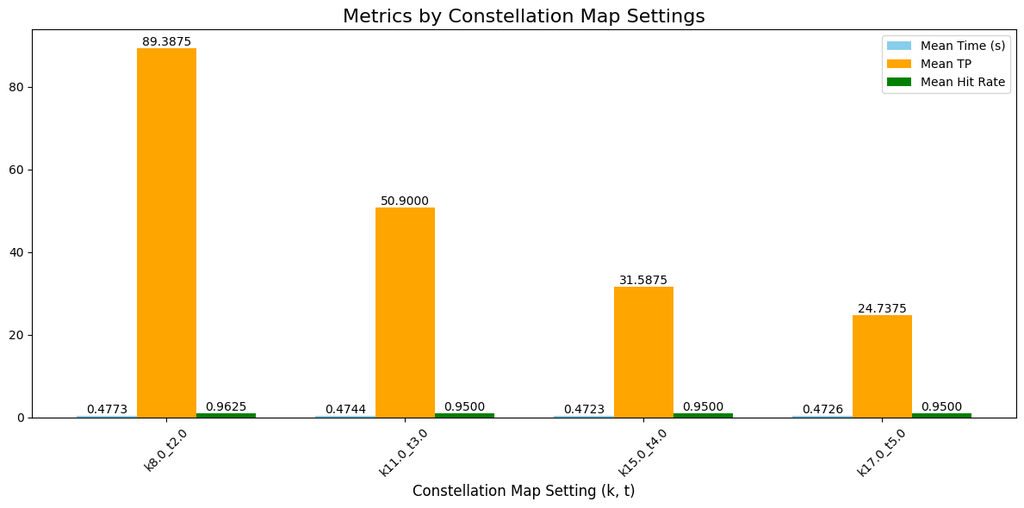

```python
import matplotlib.pyplot as plt
import numpy as np

def analyze_constellation_map_settings(df):
    """Analyzes and visualizes metrics by constellation map settings (dist_freq, dist_time)."""
    # Extract dist_freq and dist_time from filenames or configuration
    df["dist_freq"] = df["Source"].str.extract(r'_k(\d+)_').astype(int)
    df["dist_time"] = df["Source"].str.extract(r'_t(\d+)_').astype(int)

    # Group metrics by constellation map settings (dist_freq, dist_time)
    grouped_metrics = df.groupby(["dist_freq", "dist_time"]).agg(
        mean_time=("Time (s)", "mean"),
        mean_f_measure=("TP", "mean"),
        mean_hit_rate=("Hit", "mean")
    ).reset_index()

    # Prepare labels for constellation map settings
    settings = grouped_metrics.apply(lambda row: f"k{row['dist_freq']}_t{row['dist_time']}", axis=1)
    mean_times = grouped_metrics["mean_time"]
    mean_f_measures = grouped_metrics["mean_f_measure"]
    mean_hit_rates = grouped_metrics["mean_hit_rate"]

    # Create the bar plot
    x = np.arange(len(settings))  # Label locations
    width = 0.25  # Bar width

    fig, ax = plt.subplots(figsize=(12, 6))

    # Create bars for each metric
    bar1 = ax.bar(x - width, mean_times, width, label='Mean Time (s)', color='skyblue')
    bar2 = ax.bar(x, mean_f_measures, width, label='Mean TP', color='orange')
    bar3 = ax.bar(x + width, mean_hit_rates, width, label='Mean Hit Rate', color='green')

    # Adding labels, title, and legend
    ax.set_xlabel('Constellation Map Setting (k, t)', fontsize=12)
    ax.set_title('Metrics by Constellation Map Settings', fontsize=16)
    ax.set_xticks(x)
    ax.set_xticklabels(settings, fontsize=10, rotation=45)
    ax.legend()

    # Adding values on top of the bars
    def add_labels(bars):
        for bar in bars:
            height = bar.get_height()
            ax.text(bar.get_x() + bar.get_width() / 2.0, height, f'{height:.4f}', ha='center', va='bottom', fontsize=10)

    add_labels(bar1)
    add_labels(bar2)
    add_labels(bar3)

    plt.tight_layout()
    plt.show()

    return grouped_metrics

# Example usage
grouped_metrics = analyze_constellation_map_settings(df_combined_tol00)
```

#### Analysis of Metrics by Constellation Map Settings

1. **Mean Time (blue bars):**
   - All settings exhibit similar retrieval times, indicating no significant computational overhead differences between these configurations.
2. **Mean TP score (orange bars):**
   - The TP is decreasing with increasing `dist_freq` and `dist_time`. This is expected, as higher values lead to sparser constellation maps with fewer peaks and thus automatically a lower TP score. But since the hit-rate is very similar across all configurations, this is not a problem. The system is still able to identify the correct track.
3. **Mean Hit Rate (green bars):**
   - The mean hit rate is consistently high across all settings, ranging from `0.95` to `0.9625`.
   - The setting `k8_t2` achieves the highest hit rate of `0.9625`.

#### Conclusion:

Based on the results: All the configurations perform similarly in terms of time taken and hit rate. So the choice of the configurations is fairly arbitrary. Only the k8_t2 configuration has a slightly higher hit rate of `0.0125`compared to the other configurations so this could be the best choice for further development.

We now want to check if the results change considering the tolerance values of `1` for both `freq` and `time`. We will measure the same metrics as before.

```python
results_folder = "../evaluation"

#combined_df = load_all_results(results_folder, tolerance="tol00")
#summarize_overall_metrics(combined_df)
combined_df_2 = load_all_results(results_folder, tolerance="tol11")
sm_2 = summarize_overall_metrics(combined_df_2)
sm_2
```

Summary of Retrieval Metrics

|  | Metric | Value | File |
| --- | --- | --- | --- |
| 0 | Number of Queries | 320 |  |
| 1 | Average Time (s) | 0.55 |  |
| 2 | Median Time (s) | 0.55 |  |
| 3 | Max Time (s) | 0.71 (Query: 1092304_cut.wav) | results_original_k17_t5_tol11.csv |
| 4 | Min Time (s) | 0.54 (Query: 1330504_cut_mobile.wav) | results_mobile_k17_t5_tol11.csv |
| 5 | Average TP | 79.05 |  |
| 6 | Max TP | 254.00 (Query: 1110504_cut.wav) | results_original_k8_t2_tol11.csv |
| 7 | Min TP | 10.00 (Query: 1121404_cut_mobile.wav) | results_mobile_k17_t5_tol11.csv |
| 8 | Average Hit Rate | 0.92 |  |

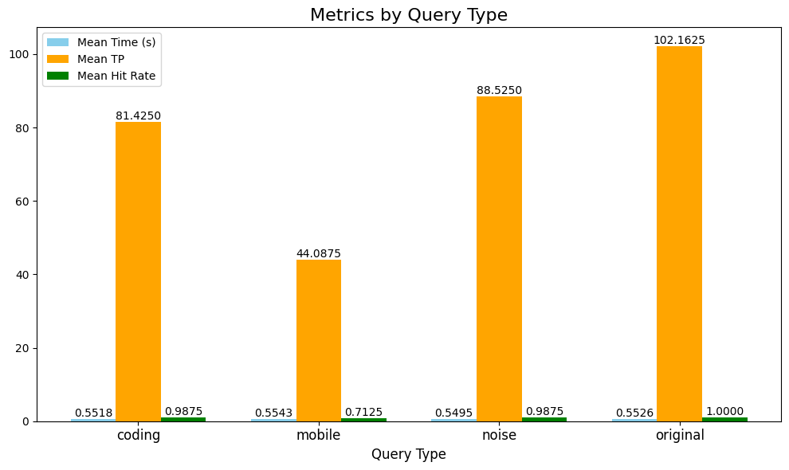

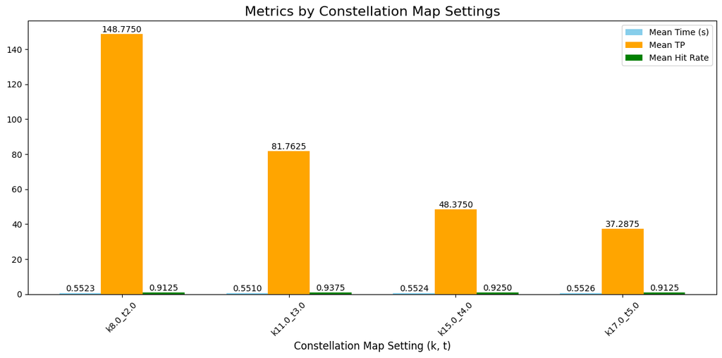

```python
#grouped_metrics_query_types_2 = analyze_query_types(combined_df)
qt_2 = analyze_query_types(combined_df_2)
#analyze_constellation_map_settings(combined_df)
ms_2 = analyze_constellation_map_settings(combined_df_2)
```

When comparing the summarizing table from the evaluation with tolerance (1,1) to the evaluation without tolerance we already notice a few things. The average time taken is around `0.1 seconds` longer. The average TP score is higher with `79.05` compared to the `49.15`without tolerance. This is expected as the system has detects more peaks with the tolerance settings. That likely also explains the longer time consumption. The hit rate is lower (`0.92` compared to `0.95`). This is still a good hit rate, but it shows that the system without tolerance is more accurate in identifying the correct track in the database. With tolerance the system miss classifies tracks in coding and noise queries and performs even worse on mobile queries. So we can conclude that the system is more accurate without tolerance.

## Final Conclusion and Report

In this project, we explored various constellation map configurations and evaluated the performance of our audio retrieval system across different query types and tolerance settings. Our objective was to identify the optimal configuration for accurate and efficient audio identification, particularly under real-world conditions involving noise, compression, and mobile recordings.

### Key Findings:

1. **Best Constellation Map Settings**:
   - The configuration `(κ=8, τ=2)` emerged as the best-performing setting, although the differences between configurations were minimal.
2. **Performance Without Tolerance**:
   - The system performed better without tolerance settings (`tol_freq=0, tol_time=0`) compared to using a tolerance of (`tol_freq=1, tol_time=1`).
   - The hit rate without tolerance was higher, reaching **95%**, while the tolerance setting reduced the hit rate to **92%**. This suggests that while tolerance allows for more flexible matching, it can introduce additional false positives, especially for distorted queries such as mobile and noise recordings.
3. **Impact of Query Transformations**:
   - **Original queries** (unmodified 10-second segments) achieved the highest retrieval accuracy (as expected), with an average TP score of **71.3**.
   - **Noise and coding queries** showed similar performance, with slightly lower TP scores.
   - **Mobile queries** were the most challenging for the system, achieving the lowest TP scores and hit rates. This highlights the difficulty of identifying audio recorded in outdoor urban environments with background noise.

### Optimal Configuration:

Based on the results, the **(κ=8, τ=2)** configuration is recommended as the best choice for future development of the audio retrieval system.

Furthermore, we recommend using **no tolerance settings (tol_freq=0, tol_time=0)** for the retrieval process. The experiments demonstrated that the system is more accurate without tolerance, as it reduces false positives and improves overall hit rates.

### Final Thoughts:

Working on this project was an exciting experience that deepened our understanding of music retrieval systems. From learning about constellation maps to implementing efficient matching functions and evaluating different configurations, We gained a lot of practical insights into audio identification.

We particularly enjoyed seeing the theoretical concepts come to life through experiments and real data analysis. The retrieval experiments demonstrated the practical challenges of matching audio under various distortions and highlighted the importance of careful parameter tuning.

Connecting this work to Milestone 2 of the course, we see a clear pathway to further improvements. By integrating the insights gained from constellation maps with advanced fingerprint matching strategies, we can achieve even more efficient and scalable audio identification systems.

Overall, this project has been a rewarding journey, and We are excited about applying these learnings in future projects and exploring more advanced music retrieval techniques.